# A snapshot of my work in R

2023-05-15

# Mass shootings in the US

In July 2012, in the aftermath of a mass shooting in a movie theater in Aurora, Colorado, [Mother Jones](https://www.motherjones.com/politics/2012/07/mass-shootings-map/) published a report on mass shootings in the United States since 1982. Importantly, they provided the underlying data set as [an open-source database](https://www.motherjones.com/politics/2012/12/mass-shootings-mother-jones-full-data/) for anyone interested in studying and understanding this criminal behavior.

## Obtain the data

```
## Rows: 125
## Columns: 14
## $ case                 <chr> "Oxford High School shooting", "San Jose VTA shoo…
## $ year                 <dbl> 2021, 2021, 2021, 2021, 2021, 2021, 2020, 2020, 2…
## $ month                <chr> "Nov", "May", "Apr", "Mar", "Mar", "Mar", "Mar", …
## $ day                  <dbl> 30, 26, 15, 31, 22, 16, 16, 26, 10, 6, 31, 4, 3, …
## $ location             <chr> "Oxford, Michigan", "San Jose, California", "Indi…
## $ summary              <chr> "Ethan Crumbley, a 15-year-old student at Oxford …
## $ fatalities           <dbl> 4, 9, 8, 4, 10, 8, 4, 5, 4, 3, 7, 9, 22, 3, 12, 5…
## $ injured              <dbl> 7, 0, 7, 1, 0, 1, 0, 0, 3, 8, 25, 27, 26, 12, 4, …
## $ total_victims        <dbl> 11, 9, 15, 5, 10, 9, 4, 5, 7, 11, 32, 36, 48, 15,…
## $ location_type        <chr> "School", "Workplace", "Workplace", "Workplace", …
## $ male                 <lgl> TRUE, TRUE, TRUE, TRUE, TRUE, TRUE, TRUE, TRUE, T…
## $ age_of_shooter       <dbl> 15, 57, 19, NA, 21, 21, 31, 51, NA, NA, 36, 24, 2…
## $ race                 <chr> NA, NA, "White", NA, NA, "White", NA, "Black", "B…
## $ prior_mental_illness <chr> NA, "Yes", "Yes", NA, "Yes", NA, NA, NA, NA, NA, …
```

```
## # A tibble: 125 × 14
##    case       year month   day location summary fatalities injured total_victims
##    <chr>     <dbl> <chr> <dbl> <chr>    <chr>        <dbl>   <dbl>         <dbl>
##  1 Oxford H…  2021 Nov      30 Oxford,… "Ethan…          4       7            11
##  2 San Jose…  2021 May      26 San Jos… "Samue…          9       0             9
##  3 FedEx wa…  2021 Apr      15 Indiana… "Brand…          8       7            15
##  4 Orange o…  2021 Mar      31 Orange,… "Amina…          4       1             5
##  5 Boulder …  2021 Mar      22 Boulder… "Ahmad…         10       0            10
##  6 Atlanta …  2021 Mar      16 Atlanta… "Rober…          8       1             9
##  7 Springfi…  2020 Mar      16 Springf… "Joaqu…          4       0             4
##  8 Molson C…  2020 Feb      26 Milwauk… "Antho…          5       0             5
##  9 Jersey C…  2019 Dec      10 Jersey … "David…          4       3             7
## 10 Pensacol…  2019 Dec       6 Pensaco… "Ahmed…          3       8            11
## # ℹ 115 more rows
## # ℹ 5 more variables: location_type <chr>, male <lgl>, age_of_shooter <dbl>,
## #   race <chr>, prior_mental_illness <chr>
```

| column(variable) | description |
| --- | --- |
| case | short name of incident |
| year, month, day | year, month, day in which the shooting occurred |
| location | city and state where the shooting occcurred |
| summary | brief description of the incident |
| fatalities | Number of fatalities in the incident, excluding the shooter |
| injured | Number of injured, non-fatal victims in the incident, excluding the shooter |
| total_victims | number of total victims in the incident, excluding the shooter |
| location_type | generic location in which the shooting took place |
| male | logical value, indicating whether the shooter was male |
| age_of_shooter | age of the shooter when the incident occured |
| race | race of the shooter |
| prior_mental_illness | did the shooter show evidence of mental illness prior to the incident? |

## Explore the data

### Specific questions

- Generate a data frame that summarizes the number of mass shootings per year.

```r
shootings_per_year <- mass_shootings %>%

  group_by(year) %>% #grouping for summary calculations

  summarise(shootings_per_year = n())

shootings_per_year
```

```
## # A tibble: 37 × 2
##     year shootings_per_year
##    <dbl>              <int>
##  1  1982                  1
##  2  1984                  2
##  3  1986                  1
##  4  1987                  1
##  5  1988                  1
##  6  1989                  2
##  7  1990                  1
##  8  1991                  3
##  9  1992                  2
## 10  1993                  4
## # ℹ 27 more rows
```

The amount of mass shootings per year has increased over the years, with 2018 having the most amount of mass shootings at 12.

- Generate a bar chart that identifies the number of mass shooters associated with each race category. The bars should be sorted from highest to lowest and each bar should show its number.

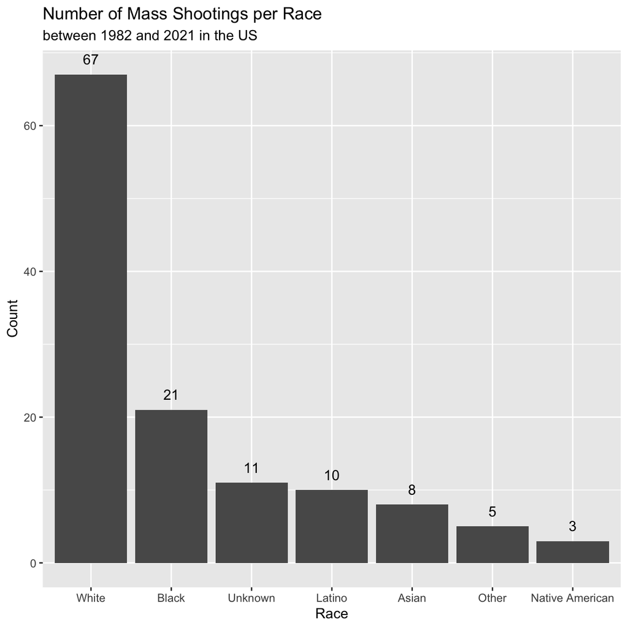

```r
#transforming the data before plotting
shootings_per_race <- mass_shootings %>%

  group_by(race)  %>%

  mutate(race_new = ifelse(is.na(race),"Unknown",race)) %>% #Replacing NA with a String for the reorder

  mutate(race_count = n()) #counting for the reorder


#plotting the data in a barchart
ggplot(shootings_per_race, aes(x = reorder(race_new,-race_count))) +

  geom_bar() +

  geom_text(stat = "count", aes(label = after_stat(count)), vjust = -1) + #adding number counts

  labs(title= "Number of Mass Shootings per Race", subtitle = "between 1982 and 2021 in the US", x= "Race", y = "Count")
```

- Generate a boxplot visualizing the number of total victims, by type of location.

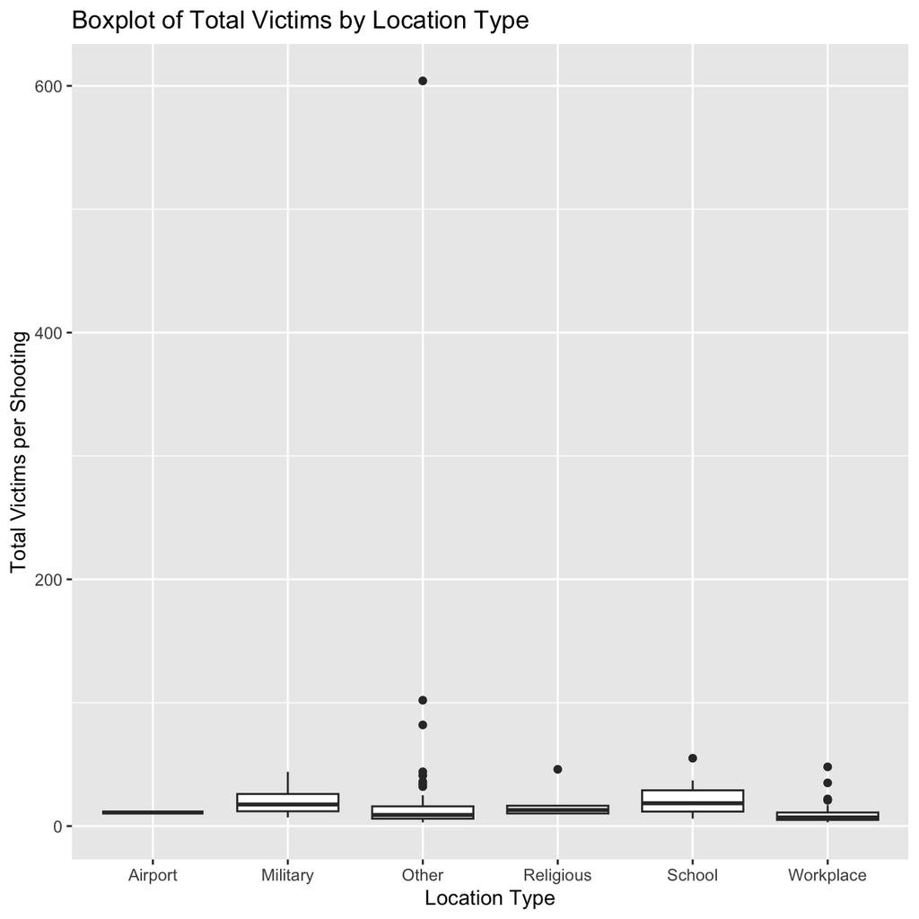

```r
ggplot(mass_shootings, aes(location_type,total_victims)) +

  geom_boxplot() +

  labs(title = "Boxplot of Total Victims by Location Type",x= "Location Type",y= "Total Victims per Shooting")
```

- Redraw the same plot, but remove the Las Vegas Strip massacre from the dataset.

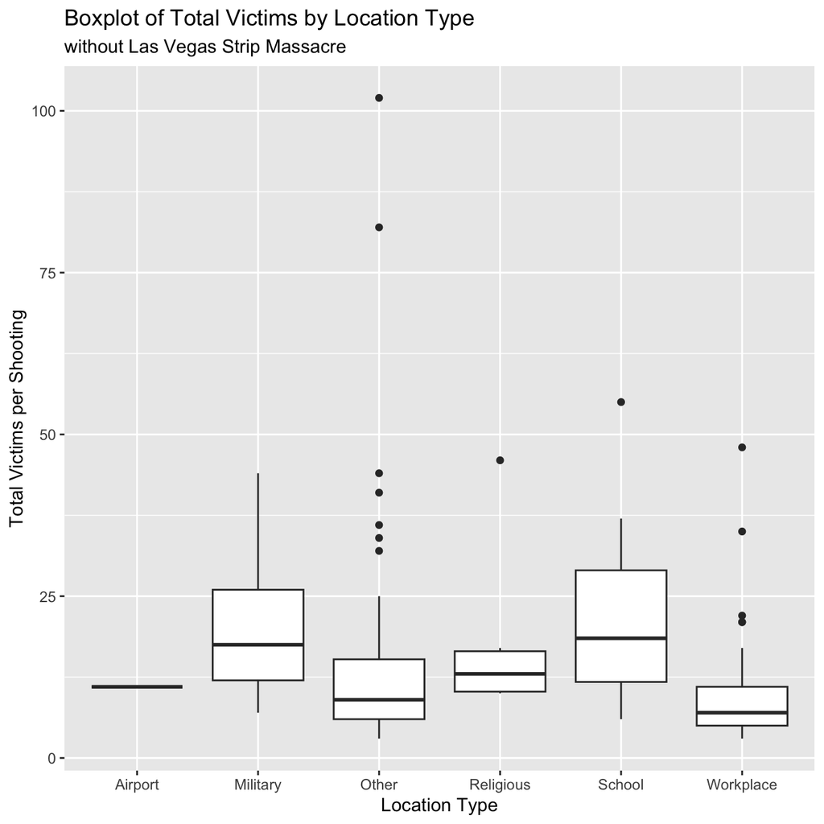

```r
#filtering out Las Vegas Massacre
victims_per_location_no_LAS <- mass_shootings %>%
  filter(!case == "Las Vegas Strip massacre") %>%
  group_by(location_type) # %>% summarise(victims = sum(total_victims))


#plotting data out
ggplot(victims_per_location_no_LAS, aes(location_type,total_victims)) +

  geom_boxplot() +

  labs(title = "Boxplot of Total Victims by Location Type",subtitle= "without Las Vegas Strip Massacre",x= "Location Type",y= "Total Victims per Shooting")
```

### More open-ended questions

Address the following questions. Generate appropriate figures/tables to support your conclusions.

- How many white males with prior signs of mental illness initiated a mass shooting after 2000?

```r
#filter for selected cases
white_male_2000up_ill <- mass_shootings %>%

  filter(race == "White",male == "TRUE",year >= 2000,prior_mental_illness == "Yes")

#count rows with with skim
skim(white_male_2000up_ill)
```

Data summary

| Name | white_male_2000up_ill |
| --- | --- |
| Number of rows | 23 |
| Number of columns | 14 |
| _______________________ |  |
| Column type frequency: |  |
| character | 7 |
| logical | 1 |
| numeric | 6 |
| ________________________ |  |
| Group variables | None |

**Variable type: character**

| skim_variable | n_missing | complete_rate | min | max | empty | n_unique | whitespace |
| --- | --- | --- | --- | --- | --- | --- | --- |
| case | 0 | 1 | 15 | 45 | 0 | 23 | 0 |
| month | 0 | 1 | 3 | 3 | 0 | 12 | 0 |
| location | 0 | 1 | 13 | 25 | 0 | 23 | 0 |
| summary | 0 | 1 | 83 | 908 | 0 | 23 | 0 |
| location_type | 0 | 1 | 5 | 9 | 0 | 4 | 0 |
| race | 0 | 1 | 5 | 5 | 0 | 1 | 0 |
| prior_mental_illness | 0 | 1 | 3 | 3 | 0 | 1 | 0 |

**Variable type: logical**

| skim_variable | n_missing | complete_rate | mean | count |
| --- | --- | --- | --- | --- |
| male | 0 | 1 | 1 | TRU: 23 |

**Variable type: numeric**

| skim_variable | n_missing | complete_rate | mean | sd | p0 | p25 | p50 | p75 | p100 | hist |
| --- | --- | --- | --- | --- | --- | --- | --- | --- | --- | --- |
| year | 0 | 1 | 2011.91 | 5.62 | 2000 | 2008.5 | 2012 | 2017.0 | 2021 | ▃▃▇▂▇ |
| day | 0 | 1 | 15.65 | 8.19 | 5 | 8.0 | 14 | 22.5 | 31 | ▇▇▂▃▅ |
| fatalities | 0 | 1 | 8.83 | 6.24 | 3 | 6.0 | 7 | 8.0 | 27 | ▇▂▁▁▁ |
| injured | 0 | 1 | 9.87 | 15.07 | 0 | 1.5 | 4 | 13.0 | 70 | ▇▂▁▁▁ |
| total_victims | 0 | 1 | 18.70 | 17.51 | 3 | 8.5 | 12 | 22.5 | 82 | ▇▃▁▁▁ |
| age_of_shooter | 0 | 1 | 30.96 | 10.14 | 19 | 22.0 | 27 | 41.0 | 48 | ▇▃▂▃▃ |

From the skim we can see that the new dataframe contains 23 rows and therefore 23 white males with prior signs of mental illness initiated a mass shooting after 2000.

- Which month of the year has the most mass shootings? Generate a bar chart sorted in chronological (natural) order (Jan-Feb-Mar- etc) to provide evidence of your answer.

```r
#changing the factor levels of the data
shootings_per_month <- mass_shootings %>%

  group_by(month) %>%

  mutate(month = factor(month, levels = c("Jan","Feb","Mar","Apr","May","Jun","Jul","Aug","Sep","Oct","Nov","Dec"))) #setting factor levels for the correct order

shootings_per_month
```

```
## # A tibble: 125 × 14
## # Groups:   month [12]
##    case       year month   day location summary fatalities injured total_victims
##    <chr>     <dbl> <fct> <dbl> <chr>    <chr>        <dbl>   <dbl>         <dbl>
##  1 Oxford H…  2021 Nov      30 Oxford,… "Ethan…          4       7            11
##  2 San Jose…  2021 May      26 San Jos… "Samue…          9       0             9
##  3 FedEx wa…  2021 Apr      15 Indiana… "Brand…          8       7            15
##  4 Orange o…  2021 Mar      31 Orange,… "Amina…          4       1             5
##  5 Boulder …  2021 Mar      22 Boulder… "Ahmad…         10       0            10
##  6 Atlanta …  2021 Mar      16 Atlanta… "Rober…          8       1             9
##  7 Springfi…  2020 Mar      16 Springf… "Joaqu…          4       0             4
##  8 Molson C…  2020 Feb      26 Milwauk… "Antho…          5       0             5
##  9 Jersey C…  2019 Dec      10 Jersey … "David…          4       3             7
## 10 Pensacol…  2019 Dec       6 Pensaco… "Ahmed…          3       8            11
## # ℹ 115 more rows
## # ℹ 5 more variables: location_type <chr>, male <lgl>, age_of_shooter <dbl>,
## #   race <chr>, prior_mental_illness <chr>
```

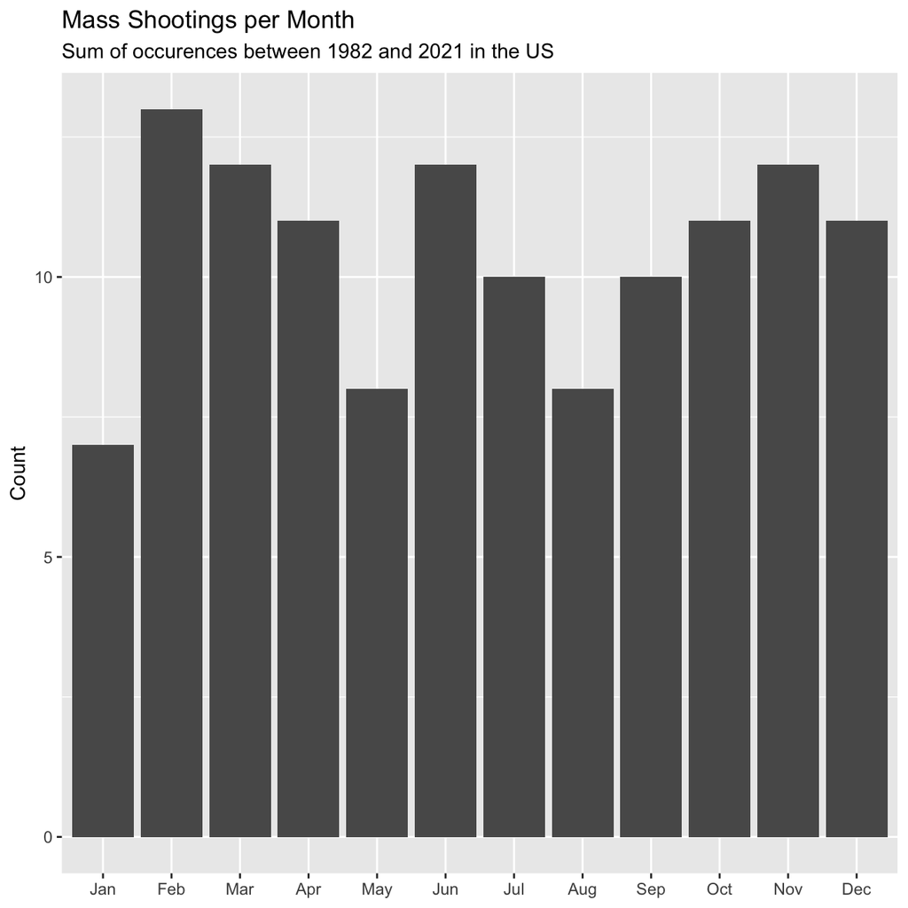

```r
#plotting the data
ggplot(shootings_per_month, aes(month)) +

  geom_bar() +

  labs(title= "Mass Shootings per Month", subtitle = "Sum of occurences between 1982 and 2021 in the US", x = NULL, y= "Count")
```

As we can see in the graph, February seems to have the most mass shootings over the years.

- How does the distribution of mass shooting fatalities differ between White and Black shooters? What about White and Latino shooters?

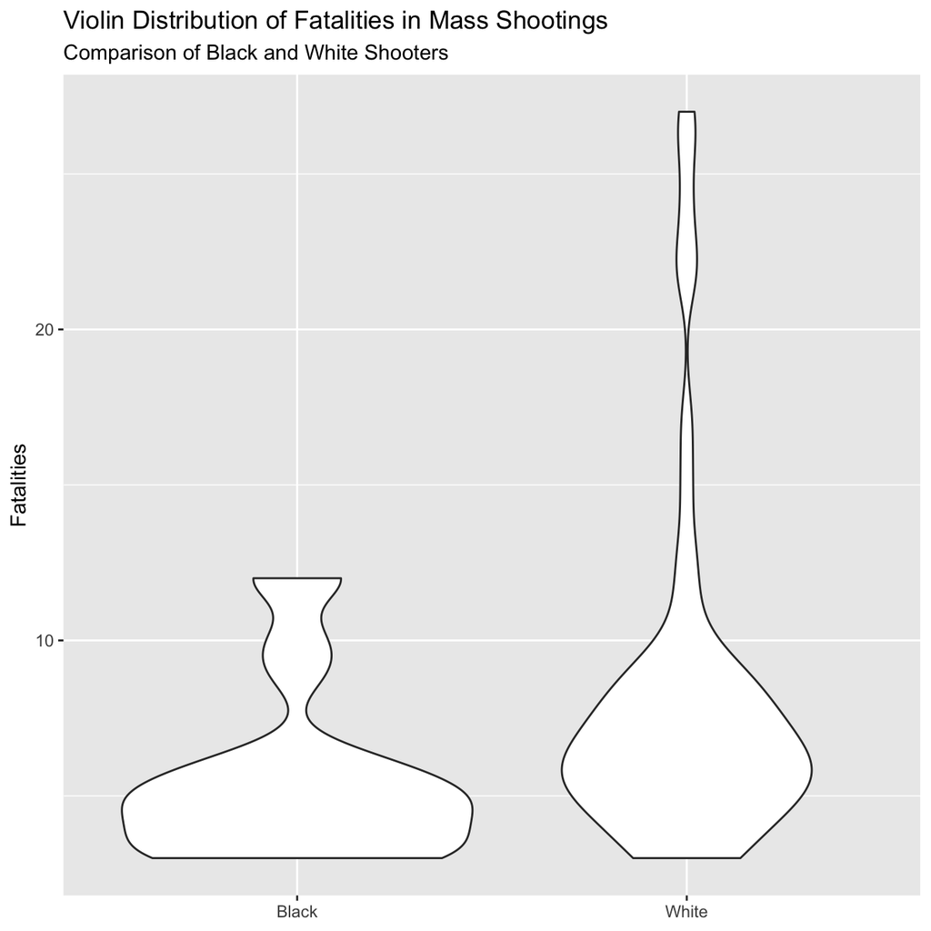

```r
#filtering and plotting for black/white distribution
shootings_white_black <- mass_shootings %>%

  filter(race %in% c("White","Black"), !case =="Las Vegas Strip massacre") #ignoring the LVS Massacre

ggplot(shootings_white_black, aes(race,fatalities)) +

  geom_violin() +

  labs(title = "Violin Distribution of Fatalities in Mass Shootings",subtitle = "Comparison of Black and White Shooters",x= NULL, y= "Fatalities")
```

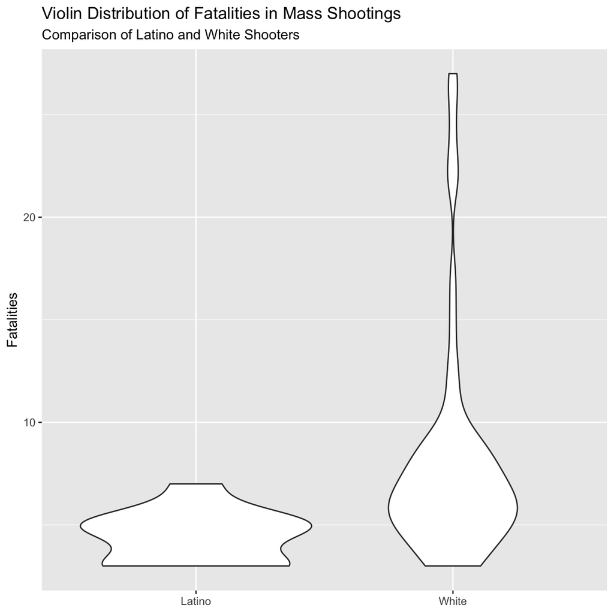

```r
#filtering and plotting for latino/white distribution
shootings_white_latino <- mass_shootings %>%

  filter(race %in% c("White","Latino"), !case =="Las Vegas Strip massacre") #ignoring the LVS Massacre

ggplot(shootings_white_latino, aes(race,fatalities)) +

  geom_violin() +

  labs(title = "Violin Distribution of Fatalities in Mass Shootings",subtitle = "Comparison of Latino and White Shooters",x= NULL, y= "Fatalities")
```

Both Black and Latino shooters caused primarily low fatalities in shootings, while White shooters caused much higher fatalities per shootings and less low fatalities in comparison. ### Very open-ended

- Are mass shootings with shooters suffering from mental illness different from mass shootings with no signs of mental illness in the shooter?

```r
#counting total shootings by mental illness
illness_count <- mass_shootings %>%

  group_by(prior_mental_illness) %>%

  summarise(count = n())

illness_count #17 62
```

```
## # A tibble: 3 × 2
##   prior_mental_illness count
##   <chr>                <int>
## 1 No                      17
## 2 Yes                     62
## 3 <NA>                    46
```

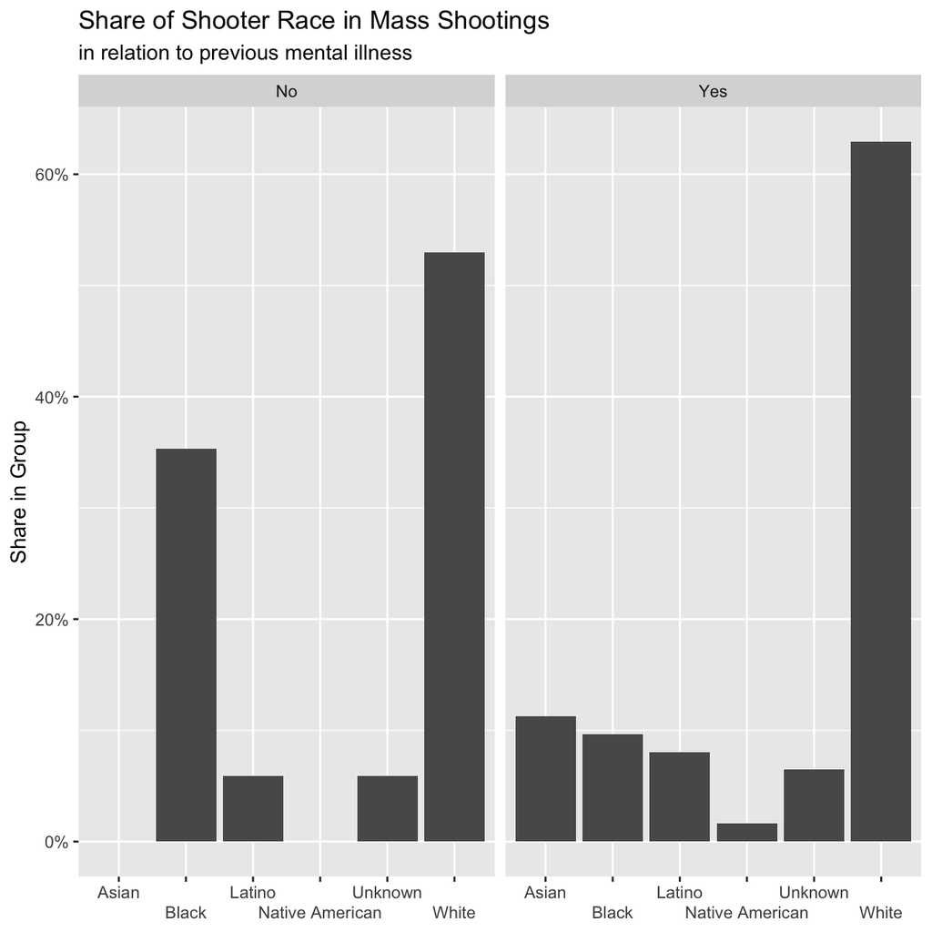

```r
#assessing the race shares of shooters by mental illness
illness_by_race <- mass_shootings %>%

  mutate(race_new = ifelse(is.na(race),"Unknown",race)) %>%

  group_by(prior_mental_illness,race_new) %>%

  summarise(count = n(), .groups = "drop_last") %>%

  mutate(total_of_group = case_when((prior_mental_illness == "No")~ 17, (prior_mental_illness == "Yes")~ 62 )) %>% #adding total shootings by mental illness

  mutate(share_in_group_total = count/total_of_group) %>% #calculating share

  filter(!total_of_group == is.na(total_of_group)) #dropping unknowns


#plotting the calculated data
ggplot(illness_by_race, aes(race_new,share_in_group_total)) +

  geom_col() +

  facet_wrap(~prior_mental_illness, ncol = 2 ) +

  scale_x_discrete(guide = guide_axis(n.dodge=2)) +

  labs(title = "Share of Shooter Race in Mass Shootings",subtitle = "in relation to previous mental illness",x= NULL, y= "Share in Group") +

  scale_y_continuous(labels=scales::percent_format())
```

1. Relationship between race and mental illness: White shooters have a higher share group totals when showing signs of mental illness. Only Asians and Native Americans with signs of mental illness have commited mass shootings.

```r
#assessing the share of fatalities of total victims by mentall illness
illness_by_victim_type <- mass_shootings %>%

  mutate(fatality_share = fatalities/total_victims) %>%

  select(prior_mental_illness,fatality_share) %>%

  group_by(prior_mental_illness)


#quick stats
skim(illness_by_victim_type)
```

Data summary

| Name | illness_by_victim_type |
| --- | --- |
| Number of rows | 125 |
| Number of columns | 2 |
| _______________________ |  |
| Column type frequency: |  |
| numeric | 1 |
| ________________________ |  |
| Group variables | prior_mental_illness |

**Variable type: numeric**

| skim_variable | prior_mental_illness | n_missing | complete_rate | mean | sd | p0 | p25 | p50 | p75 | p100 | hist |
| --- | --- | --- | --- | --- | --- | --- | --- | --- | --- | --- | --- |
| fatality_share | No | 0 | 1 | 0.65 | 0.21 | 0.29 | 0.55 | 0.71 | 0.78 | 1 | ▃▅▁▇▂ |
| fatality_share | Yes | 0 | 1 | 0.62 | 0.26 | 0.14 | 0.44 | 0.61 | 0.86 | 1 | ▃▅▇▅▇ |
| fatality_share | NA | 0 | 1 | 0.64 | 0.28 | 0.10 | 0.41 | 0.71 | 0.88 | 1 | ▃▃▃▆▇ |

2. Relationship between victim type and mental illness: From the skim we can see that shooters with mental illness have on average a slightly lower fatality rate in total victims but the standard distribution is larger and therefore the fatality rate is more volatile
- Assess the relationship between mental illness and total victims, mental illness and location type, and the intersection of all three variables.

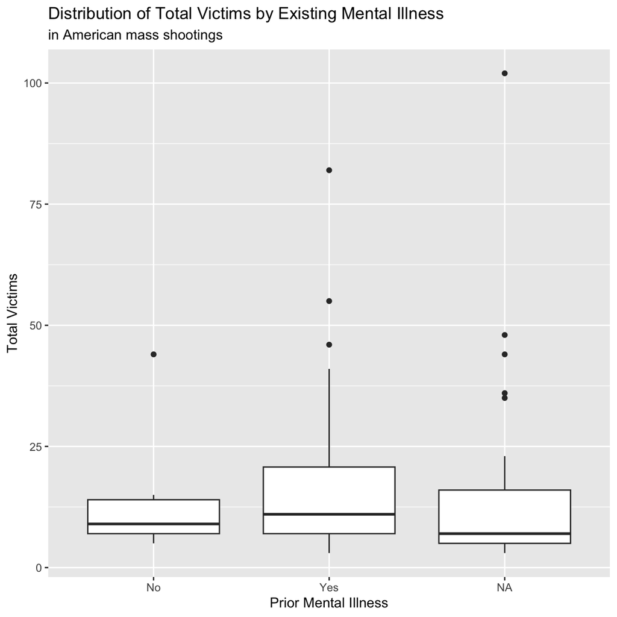

```r
#Plotting the relationship between mental illness and total victims
ggplot(victims_per_location_no_LAS, aes(prior_mental_illness, total_victims) ) +

  geom_boxplot() +

  labs(title = "Distribution of Total Victims by Existing Mental Illness",subtitle = "in American mass shootings",x = "Prior Mental Illness", y = "Total Victims")
```

For the analysis we will disregard the unknowns for mental illness

1. Shooters with mental illness hit on average more victims than mentally sound shooters. They also have higher maximums and outliers

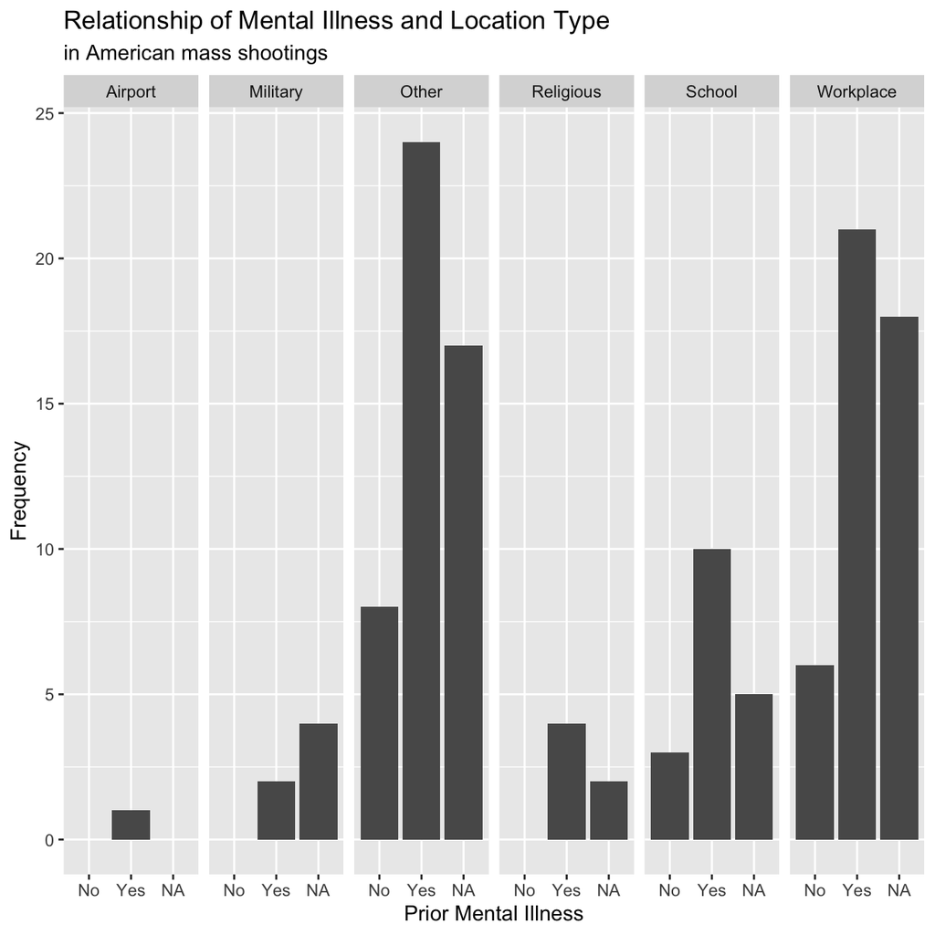

```r
#Plotting the relationship between mental illness and location type
ggplot(mass_shootings, aes(prior_mental_illness)) +

  geom_bar() +

  facet_grid(~location_type) +

  labs(title = "Relationship of Mental Illness and Location Type", subtitle = "in American mass shootings", x = "Prior Mental Illness", y = "Frequency")
```

2. Mentally sound shooters do not seem to target Airports, Military or Religious targets. Mentally ill shooters have more shootings in every single location type

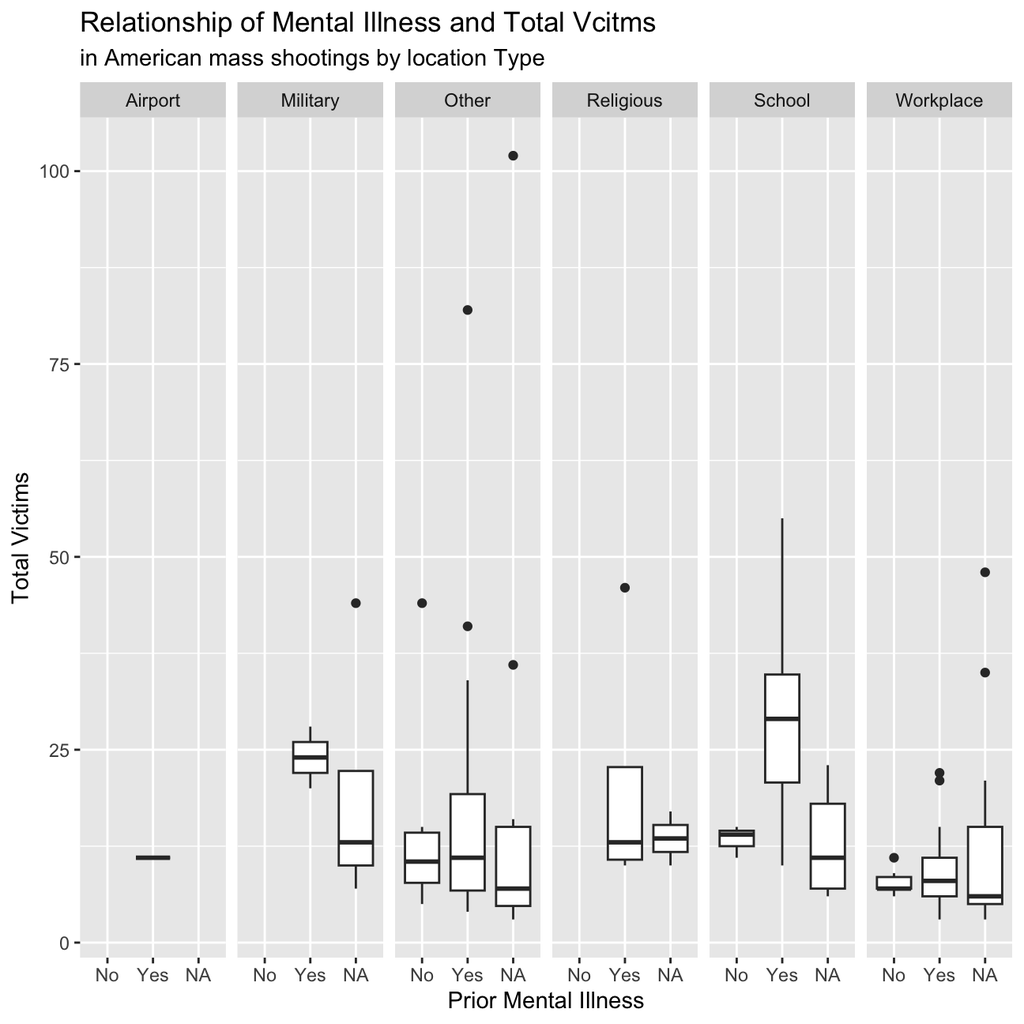

```r
#Plotting the relationship between all three variables via facet_grid
ggplot(victims_per_location_no_LAS, aes(prior_mental_illness, total_victims) ) +

  geom_boxplot() +

  facet_grid(~location_type) +

  labs(title = "Relationship of Mental Illness and Total Vcitms", subtitle = "in American mass shootings by location Type", x = "Prior Mental Illness", y = "Total Victims")
```

3. The number of total victims is on average higher for every location type where shooters had a mental illness. Especially for school the victim distribution differs significantly